# note4

zzy

2016年10月12日

## 通过ggplot创建图形对象

```r
library(ggplot2)
p <- ggplot(diamonds, aes(carat, price, colour = cut))
```

## 添加“点”几何对象

```r
p <- p + layer(geom = "point")
```

## 例：手动创建图形对象并添加图层

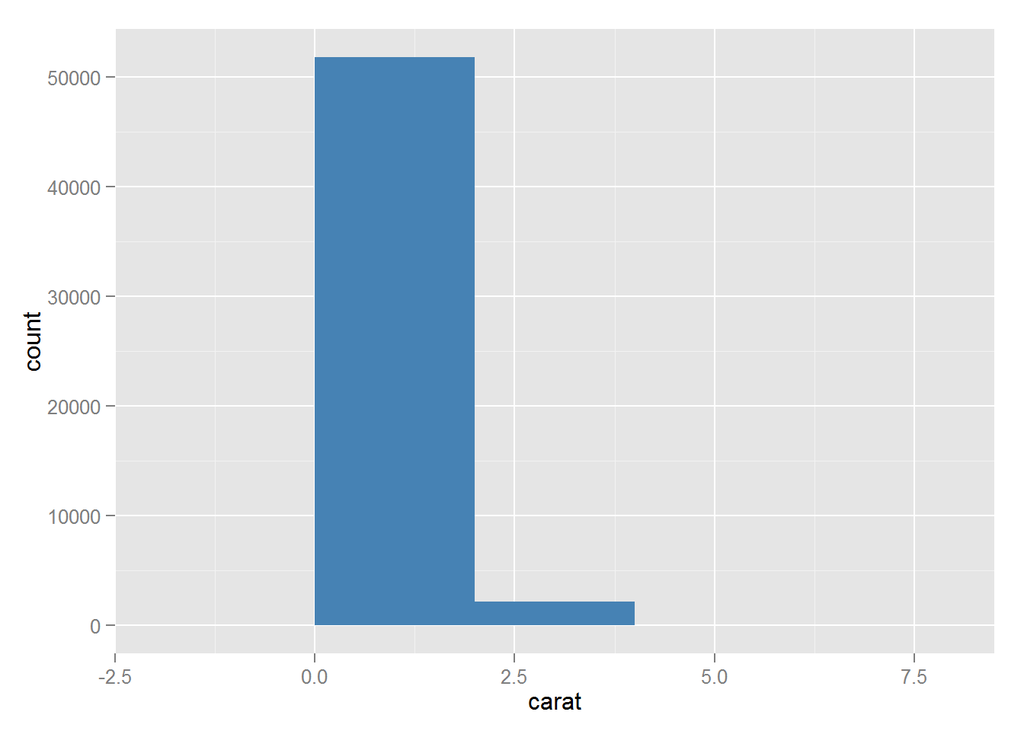

```r
p <- ggplot(diamonds, aes(x = carat))
p <- p + layer(geom = "bar", geom_params = list(fill = "steelblue"), stat = "bin",
    stat_params = list(binwidth = 2))
p
```

## 应用“快捷函数”，得到与上例相同的图形

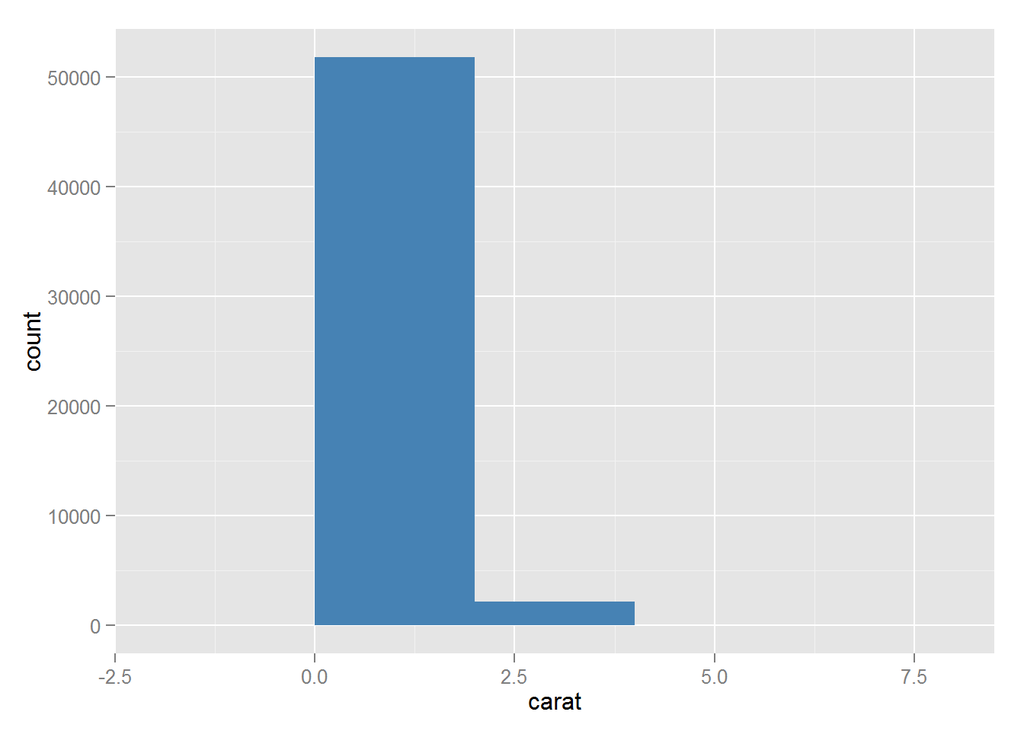

```r
p + geom_histogram(binwidth = 2, fill = "steelblue")
```

## 在用ggplot创建的图形对象上添加图层

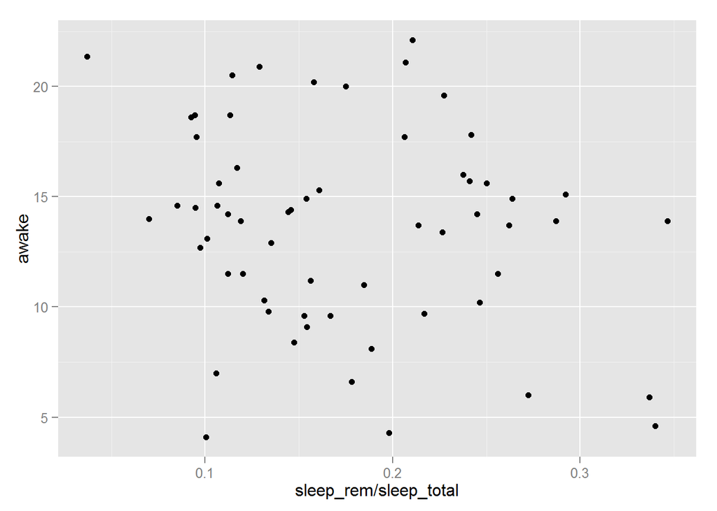

```r
ggplot(msleep, aes(sleep_rem/sleep_total, awake)) + geom_point()
```

## 等价于

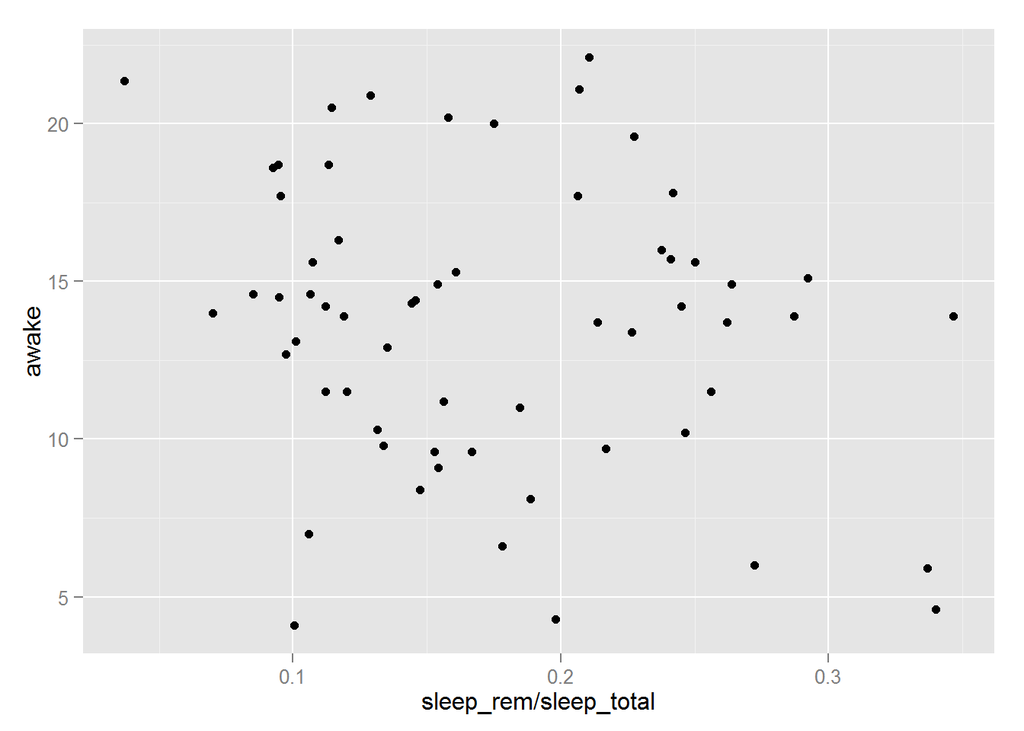

```r
qplot(sleep_rem/sleep_total, awake, data = msleep)
```

## 也可以给qplot添加图层

```r
qplot(sleep_rem/sleep_total, awake, data = msleep) + geom_smooth()
```

[output not shown]

```
## geom_smooth: method="auto" and size of largest group is <1000, so using loess. Use 'method = x' to change the smoothing method.
```

## 等价于

```r
qplot(sleep_rem/sleep_total, awake, data = msleep, geom = c("point", "smooth"))
```

[output not shown]

```
## geom_smooth: method="auto" and size of largest group is <1000, so using loess. Use 'method = x' to change the smoothing method.
```

## 或

```r
ggplot(msleep, aes(sleep_rem/sleep_total, awake)) + geom_point() + geom_smooth()
```

[output not shown]

```
## geom_smooth: method="auto" and size of largest group is <1000, so using loess. Use 'method = x' to change the smoothing method.
```

## 例：summary给出图形对象的默认设置和每个图层的信息

```r
p <- ggplot(msleep, aes(sleep_rem/sleep_total, awake))
summary(p)
```

```
## data: name, genus, vore, order, conservation, sleep_total,
##   sleep_rem, sleep_cycle, awake, brainwt, bodywt [83x11]
## mapping:  x = sleep_rem/sleep_total, y = awake
## faceting: facet_null()
```

```r
p <- p + geom_point()
summary(p)
```

```
## data: name, genus, vore, order, conservation, sleep_total,
##   sleep_rem, sleep_cycle, awake, brainwt, bodywt [83x11]
## mapping:  x = sleep_rem/sleep_total, y = awake
## faceting: facet_null()
## -----------------------------------
## geom_point: na.rm = FALSE
## stat_identity:
## position_identity: (width = NULL, height = NULL)
```

## 例：用不同的数据初始化后添加相同的图层

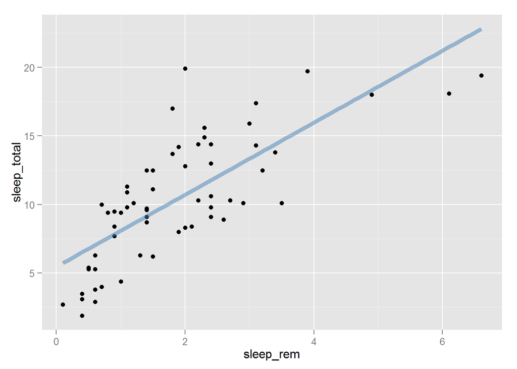

```r
library(scales)
bestfit <- geom_smooth(method = "lm", se = F, colour = alpha("steelblue", 0.5),
    size = 2)
qplot(sleep_rem, sleep_total, data = msleep) + bestfit
```

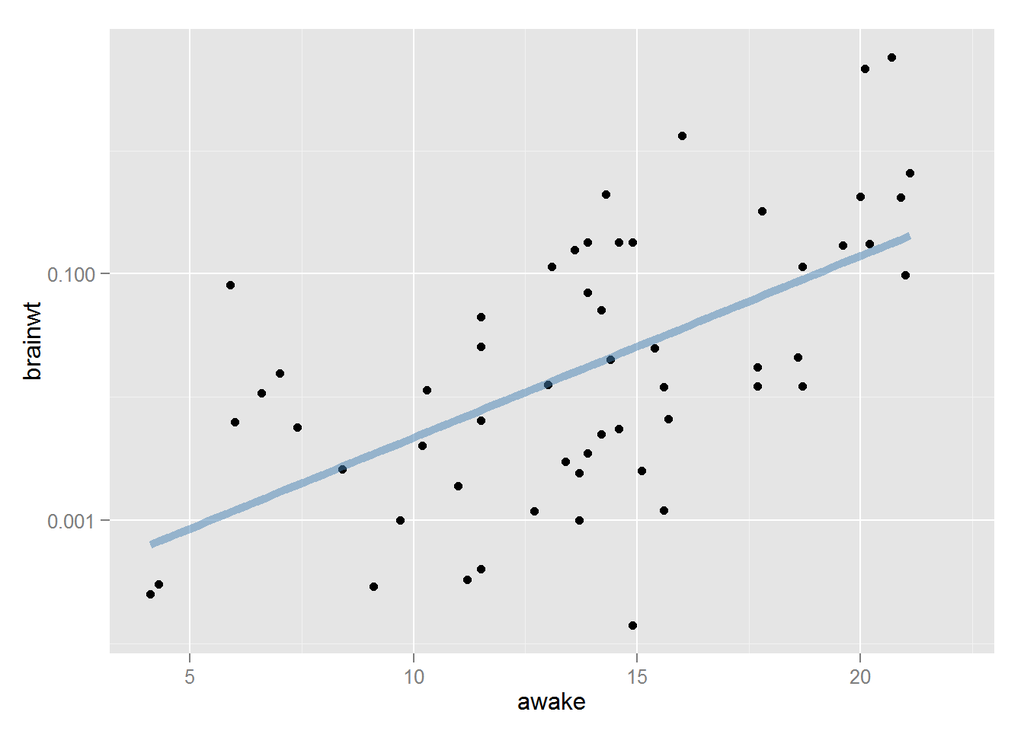

```r
qplot(awake, brainwt, data = msleep, log = "y") + bestfit
```

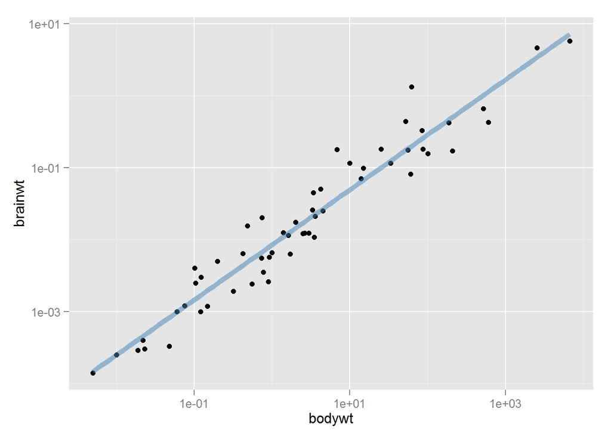

```r
qplot(bodywt, brainwt, data = msleep, log = "xy") + bestfit
```

## 用%+%添加新的数据集来代替原来的数据集

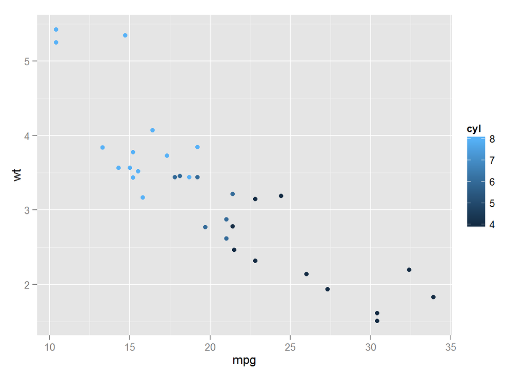

```r
p <- ggplot(mtcars, aes(mpg, wt, colour = cyl)) + geom_point()
p
```

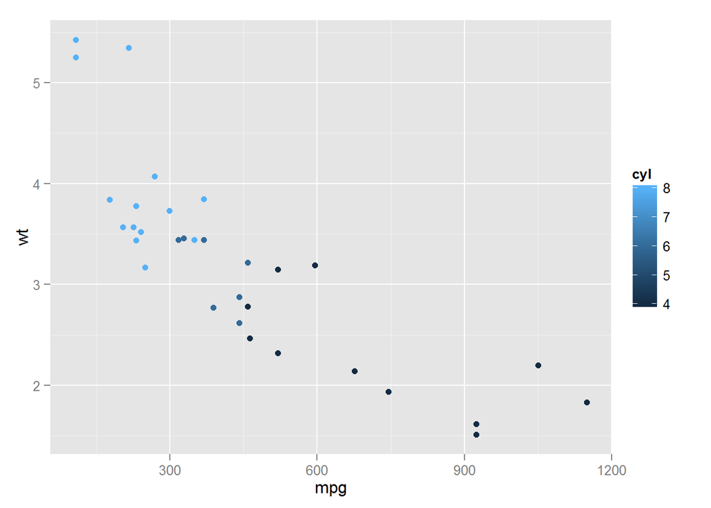

```r
mtcars <- transform(mtcars, mpg = mpg^2)
p %+% mtcars
```

## aes函数的参数

```r
aes(x = weight, y = height, colour = age)
```

```
## List of 3
##  $ x     : symbol weight
##  $ y     : symbol height
##  $ colour: symbol age
```

## 也可以使用变量的函数值作为参数

```r
aes(weight, height, colour = sqrt(age))
```

```
## List of 3
##  $ x     : symbol weight
##  $ y     : symbol height
##  $ colour: language sqrt(age)
```

```r
p <- ggplot(mtcars)
summary(p)
```

```
## data: mpg, cyl, disp, hp, drat, wt, qsec, vs, am, gear, carb
##   [32x11]
## faceting: facet_null()
```

```r
p <- p + aes(wt, hp)
summary(p)
```

```
## data: mpg, cyl, disp, hp, drat, wt, qsec, vs, am, gear, carb
##   [32x11]
## mapping:  x = wt, y = hp
## faceting: facet_null()
```

## 使用默认的参数映射来添加图层

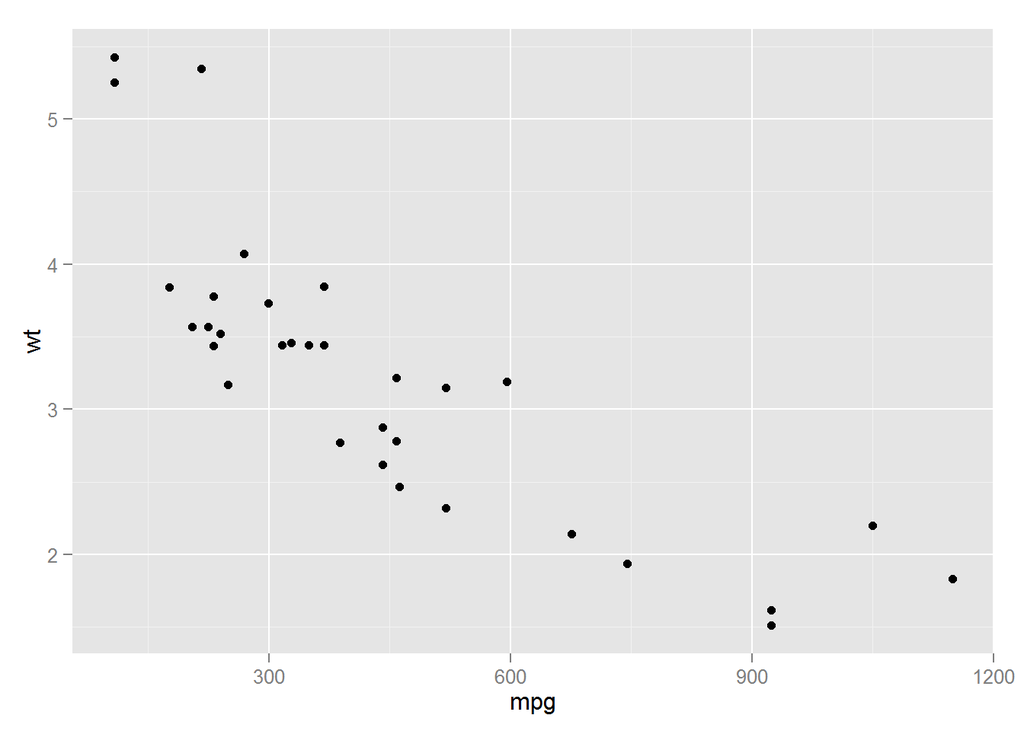

```r
p <- ggplot(mtcars, aes(x = mpg, y = wt))
p + geom_point()
```

## 图4.1 修改图形属性。用factor(cyl)修改颜色(左)，用disp修改y坐标(右)。

## 一个图层里设定的图形属性映射只对该图层起作用。除非修改默认的标度，否则坐标标签及图例都会根据图形对象的默认设置而生成。

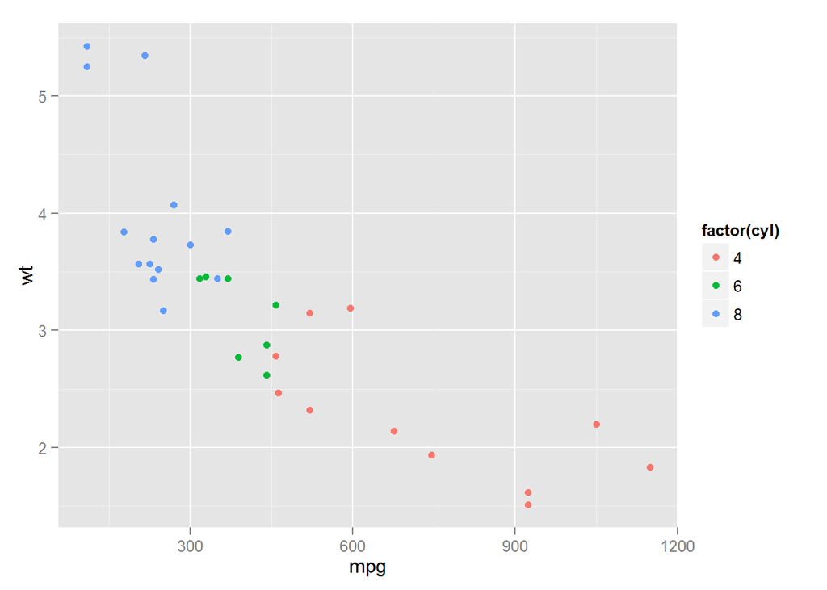

```r
p + geom_point(aes(colour = factor(cyl)))
```

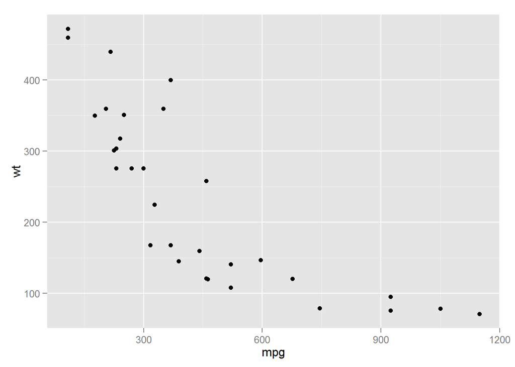

```r
p + geom_point(aes(y = disp))
```

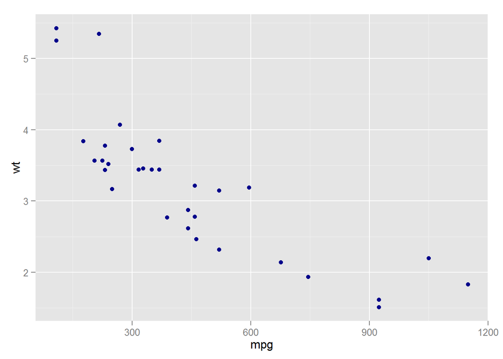

```r
p <- ggplot(mtcars, aes(mpg, wt))
p + geom_point(colour = "darkblue")
```

## 注意这里将颜色映射到’darkblue’与上面将颜色设定给’darkblue’的区别

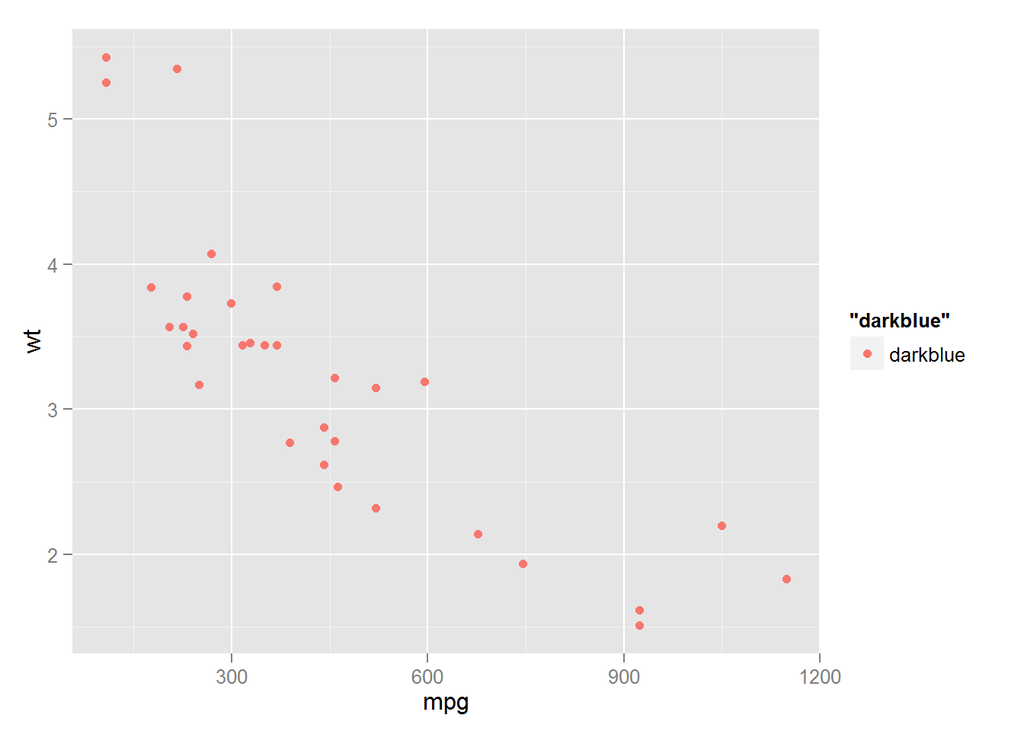

```r
p + geom_point(aes(colour = "darkblue"))
```

## The difference between (left) setting colour to ‘darkblue’ and (right) mapping colour to ‘darkblue’. When ‘darkblue’ is mapped to colour, it is treated as a regular value and scaled with the default colour scale. This results in pinkish points and a legend.

## 图4.2

## 将颜色设定为’darkblue’(左)与将颜色映射到’darkblue’(右)的区别。当颜色映射到’darkblue’时，’darkblue’将被看作一个普通的字符串，使用默认的颜色标度进行标度转换，结果得到了粉红色的点和图例。

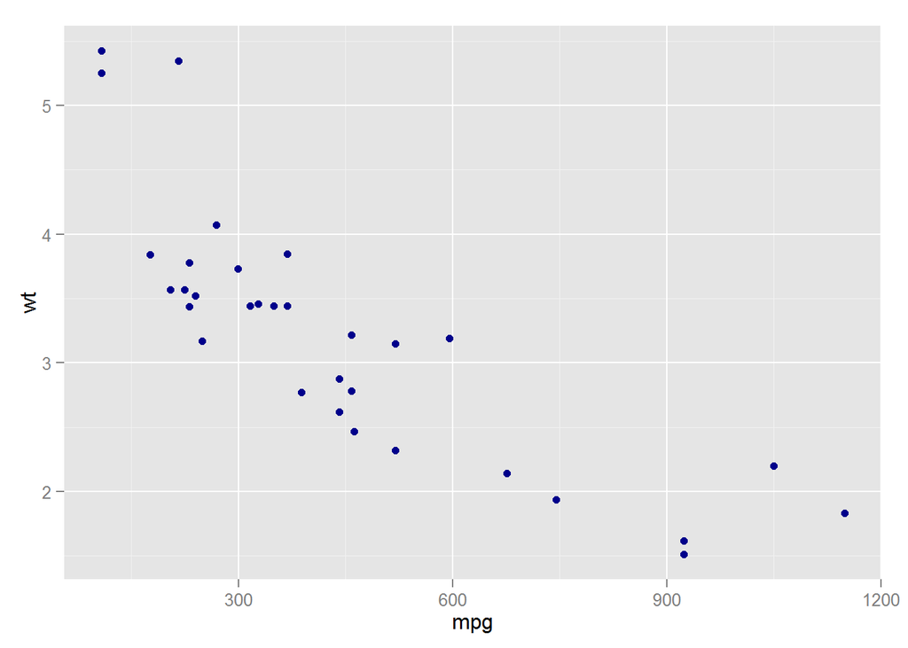

```r
qplot(mpg, wt, data = mtcars, colour = I("darkblue"))
```

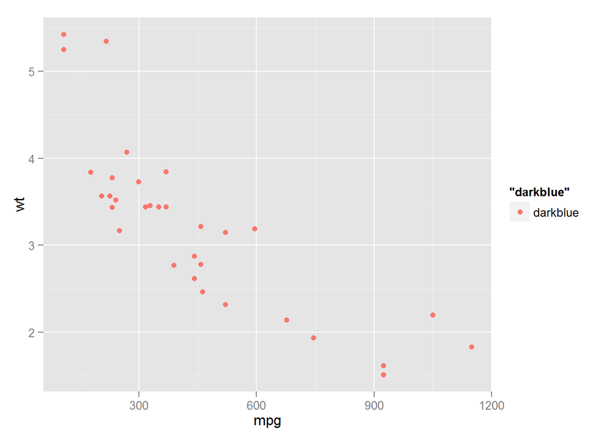

```r
qplot(mpg, wt, data = mtcars, colour = "darkblue")
```

## 图4.3

## 正确分组时(分组变量group=Subject)每个个体的折线图(左)。错误的 分组时连接所有观测点的折线图(右)。此处省略了分组图形属性，效果等同于group =1。

```r
data(Oxboys, package = "nlme")
```

## 左图的代码

```r
p <- ggplot(Oxboys, aes(age, height, group = Subject)) + geom_line()
```

## 或

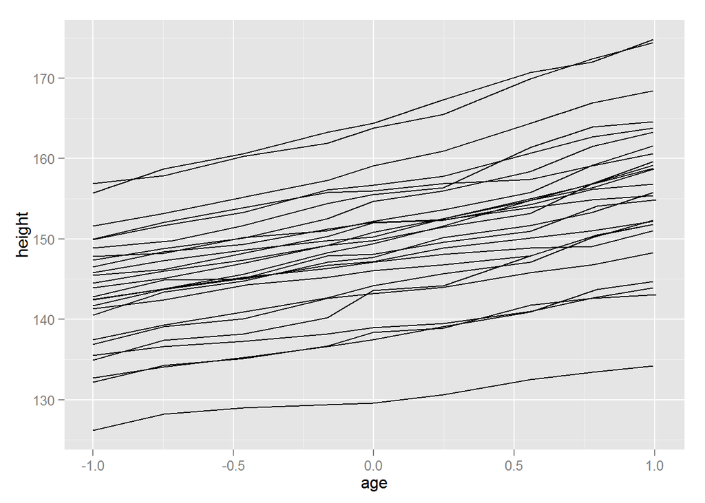

```r
qplot(age, height, data = Oxboys, group = Subject, geom = "line")
```

## 右图的代码

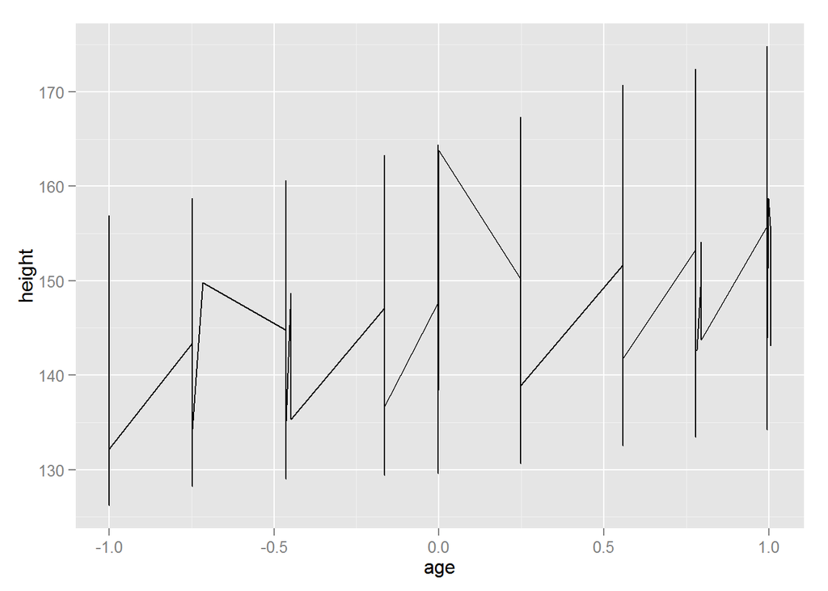

```r
qplot(age, height, data = Oxboys, geom = "line")
```

## 图4.4

## 给Oxboys数据添加光滑曲线。左图用了和折线图同样的分组变量，得到了每个男孩的拟合直线。右图在平滑层里用了aes(group = 1)，得到了所有男孩的拟合直线。

## 左图

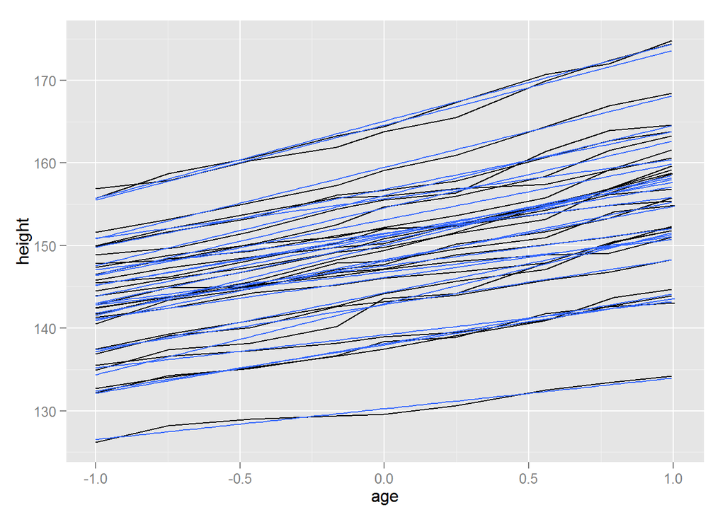

```r
p + geom_smooth(aes(group = Subject), method = "lm", se = F)
```

# 或

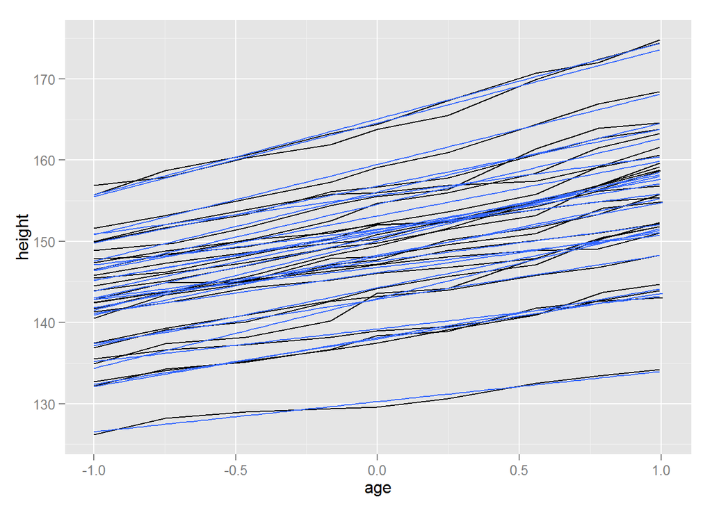

```r
qplot(age, height, data = Oxboys, group = Subject, geom = "line") + geom_smooth(method = "lm", se = F)
```

# 右图

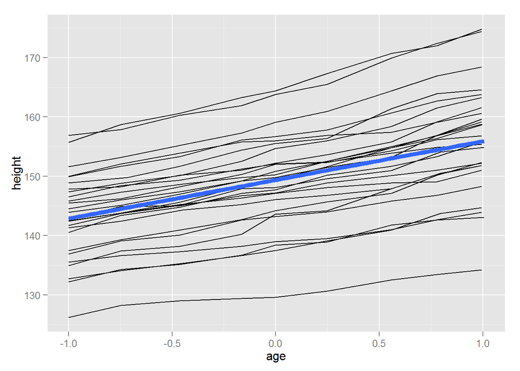

```r
p + geom_smooth(aes(group = 1), method = "lm", size = 2, se = F)
```

# 或

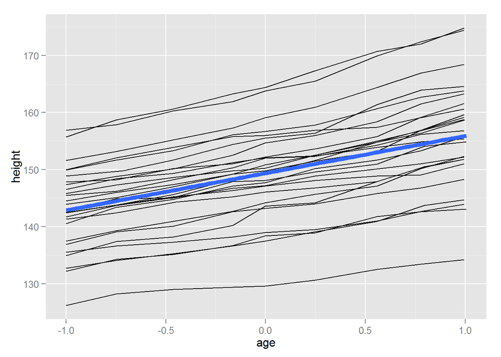

```r
qplot(age, height, data = Oxboys, group = Subject, geom = "line") + geom_smooth(aes(group = 1),
    method = "lm", size = 2, se = F)
```